# Risk Factor Analysis

## Outcome Variable

**Outcome Variable:** ever_co

## Predictor Variables

**Intervention Variable:** predfeed6

**Adjustment Set:**

- arm
- sex
- month
- brthmon
- W_mage
- meducyrs
- feducyrs
- hhwealth_quart
- hfoodsec
- W_mhtcm
- vagbrth
- W_gagebrth
- W_birthwt
- W_birthlen
- W_nrooms
- W_nchldlt5
- W_parity
- impfloor
- impsan
- safeh20
- delta_W_mage
- delta_meducyrs
- delta_feducyrs
- delta_hhwealth_quart
- delta_hfoodsec
- delta_W_mhtcm
- delta_vagbrth
- delta_W_gagebrth
- delta_W_birthwt
- delta_W_birthlen
- delta_W_nrooms
- delta_W_nchldlt5
- delta_W_parity
- delta_impfloor
- delta_impsan
- delta_safeh20

## Stratifying Variables

The analysis was stratified on these variable(s):

- agecat
- studyid
- country

## Data Summary

| agecat | studyid | country | predfeed6 | ever_co | n_cell | n |
| --- | --- | --- | --- | --- | --- | --- |
| 0-24 months | ki0047075b-MAL-ED | BANGLADESH | 1 | 0 | 101 | 238 |
| 0-24 months | ki0047075b-MAL-ED | BANGLADESH | 1 | 1 | 24 | 238 |
| 0-24 months | ki0047075b-MAL-ED | BANGLADESH | 0 | 0 | 98 | 238 |
| 0-24 months | ki0047075b-MAL-ED | BANGLADESH | 0 | 1 | 15 | 238 |
| 0-24 months | ki0047075b-MAL-ED | BRAZIL | 1 | 0 | 36 | 212 |
| 0-24 months | ki0047075b-MAL-ED | BRAZIL | 1 | 1 | 0 | 212 |
| 0-24 months | ki0047075b-MAL-ED | BRAZIL | 0 | 0 | 174 | 212 |
| 0-24 months | ki0047075b-MAL-ED | BRAZIL | 0 | 1 | 2 | 212 |
| 0-24 months | ki0047075b-MAL-ED | INDIA | 1 | 0 | 17 | 234 |
| 0-24 months | ki0047075b-MAL-ED | INDIA | 1 | 1 | 2 | 234 |
| 0-24 months | ki0047075b-MAL-ED | INDIA | 0 | 0 | 165 | 234 |
| 0-24 months | ki0047075b-MAL-ED | INDIA | 0 | 1 | 50 | 234 |
| 0-24 months | ki0047075b-MAL-ED | NEPAL | 1 | 0 | 25 | 235 |
| 0-24 months | ki0047075b-MAL-ED | NEPAL | 1 | 1 | 4 | 235 |
| 0-24 months | ki0047075b-MAL-ED | NEPAL | 0 | 0 | 189 | 235 |
| 0-24 months | ki0047075b-MAL-ED | NEPAL | 0 | 1 | 17 | 235 |
| 0-24 months | ki0047075b-MAL-ED | PERU | 1 | 0 | 113 | 270 |
| 0-24 months | ki0047075b-MAL-ED | PERU | 1 | 1 | 1 | 270 |
| 0-24 months | ki0047075b-MAL-ED | PERU | 0 | 0 | 148 | 270 |
| 0-24 months | ki0047075b-MAL-ED | PERU | 0 | 1 | 8 | 270 |
| 0-24 months | ki0047075b-MAL-ED | SOUTH AFRICA | 1 | 0 | 3 | 248 |
| 0-24 months | ki0047075b-MAL-ED | SOUTH AFRICA | 1 | 1 | 0 | 248 |
| 0-24 months | ki0047075b-MAL-ED | SOUTH AFRICA | 0 | 0 | 224 | 248 |
| 0-24 months | ki0047075b-MAL-ED | SOUTH AFRICA | 0 | 1 | 21 | 248 |
| 0-24 months | ki0047075b-MAL-ED | TANZANIA, UNITED REPUBLIC OF | 1 | 0 | 2 | 248 |
| 0-24 months | ki0047075b-MAL-ED | TANZANIA, UNITED REPUBLIC OF | 1 | 1 | 0 | 248 |
| 0-24 months | ki0047075b-MAL-ED | TANZANIA, UNITED REPUBLIC OF | 0 | 0 | 223 | 248 |
| 0-24 months | ki0047075b-MAL-ED | TANZANIA, UNITED REPUBLIC OF | 0 | 1 | 23 | 248 |
| 0-24 months | ki1000109-EE | PAKISTAN | 1 | 0 | 141 | 379 |
| 0-24 months | ki1000109-EE | PAKISTAN | 1 | 1 | 82 | 379 |

[output cut: 126 more lines]

The following strata were considered:

- agecat: 0-24 months, studyid: ki0047075b-MAL-ED, country: BANGLADESH
- agecat: 0-24 months, studyid: ki0047075b-MAL-ED, country: BRAZIL
- agecat: 0-24 months, studyid: ki0047075b-MAL-ED, country: INDIA
- agecat: 0-24 months, studyid: ki0047075b-MAL-ED, country: NEPAL
- agecat: 0-24 months, studyid: ki0047075b-MAL-ED, country: PERU
- agecat: 0-24 months, studyid: ki0047075b-MAL-ED, country: SOUTH AFRICA
- agecat: 0-24 months, studyid: ki0047075b-MAL-ED, country: TANZANIA, UNITED REPUBLIC OF
- agecat: 0-24 months, studyid: ki1000109-EE, country: PAKISTAN
- agecat: 0-24 months, studyid: ki1000304b-SAS-FoodSuppl, country: INDIA
- agecat: 0-24 months, studyid: ki1113344-GMS-Nepal, country: NEPAL
- agecat: 0-24 months, studyid: ki1148112-LCNI-5, country: MALAWI
- agecat: 0-24 months, studyid: kiGH5241-JiVitA-3, country: BANGLADESH
- agecat: 0-24 months, studyid: kiGH5241-JiVitA-4, country: BANGLADESH
- agecat: 0-6 months, studyid: ki0047075b-MAL-ED, country: BANGLADESH
- agecat: 0-6 months, studyid: ki0047075b-MAL-ED, country: BRAZIL
- agecat: 0-6 months, studyid: ki0047075b-MAL-ED, country: INDIA
- agecat: 0-6 months, studyid: ki0047075b-MAL-ED, country: NEPAL
- agecat: 0-6 months, studyid: ki0047075b-MAL-ED, country: PERU
- agecat: 0-6 months, studyid: ki0047075b-MAL-ED, country: SOUTH AFRICA
- agecat: 0-6 months, studyid: ki0047075b-MAL-ED, country: TANZANIA, UNITED REPUBLIC OF
- agecat: 0-6 months, studyid: ki1000109-EE, country: PAKISTAN
- agecat: 0-6 months, studyid: ki1000304b-SAS-FoodSuppl, country: INDIA
- agecat: 0-6 months, studyid: ki1113344-GMS-Nepal, country: NEPAL
- agecat: 0-6 months, studyid: ki1148112-LCNI-5, country: MALAWI
- agecat: 0-6 months, studyid: kiGH5241-JiVitA-3, country: BANGLADESH
- agecat: 0-6 months, studyid: kiGH5241-JiVitA-4, country: BANGLADESH
- agecat: 6-24 months, studyid: ki0047075b-MAL-ED, country: BANGLADESH
- agecat: 6-24 months, studyid: ki0047075b-MAL-ED, country: BRAZIL
- agecat: 6-24 months, studyid: ki0047075b-MAL-ED, country: INDIA
- agecat: 6-24 months, studyid: ki0047075b-MAL-ED, country: NEPAL
- agecat: 6-24 months, studyid: ki0047075b-MAL-ED, country: PERU
- agecat: 6-24 months, studyid: ki0047075b-MAL-ED, country: SOUTH AFRICA
- agecat: 6-24 months, studyid: ki0047075b-MAL-ED, country: TANZANIA, UNITED REPUBLIC OF
- agecat: 6-24 months, studyid: ki1000109-EE, country: PAKISTAN
- agecat: 6-24 months, studyid: ki1000304b-SAS-FoodSuppl, country: INDIA
- agecat: 6-24 months, studyid: ki1113344-GMS-Nepal, country: NEPAL
- agecat: 6-24 months, studyid: ki1148112-LCNI-5, country: MALAWI
- agecat: 6-24 months, studyid: kiGH5241-JiVitA-3, country: BANGLADESH
- agecat: 6-24 months, studyid: kiGH5241-JiVitA-4, country: BANGLADESH

### Dropped Strata

Some strata were dropped due to rare outcomes:

- agecat: 0-24 months, studyid: ki0047075b-MAL-ED, country: BRAZIL
- agecat: 0-24 months, studyid: ki0047075b-MAL-ED, country: INDIA
- agecat: 0-24 months, studyid: ki0047075b-MAL-ED, country: NEPAL
- agecat: 0-24 months, studyid: ki0047075b-MAL-ED, country: PERU
- agecat: 0-24 months, studyid: ki0047075b-MAL-ED, country: SOUTH AFRICA
- agecat: 0-24 months, studyid: ki0047075b-MAL-ED, country: TANZANIA, UNITED REPUBLIC OF
- agecat: 0-24 months, studyid: ki1000304b-SAS-FoodSuppl, country: INDIA
- agecat: 0-24 months, studyid: ki1148112-LCNI-5, country: MALAWI
- agecat: 0-6 months, studyid: ki0047075b-MAL-ED, country: BANGLADESH
- agecat: 0-6 months, studyid: ki0047075b-MAL-ED, country: BRAZIL
- agecat: 0-6 months, studyid: ki0047075b-MAL-ED, country: INDIA
- agecat: 0-6 months, studyid: ki0047075b-MAL-ED, country: NEPAL
- agecat: 0-6 months, studyid: ki0047075b-MAL-ED, country: PERU
- agecat: 0-6 months, studyid: ki0047075b-MAL-ED, country: SOUTH AFRICA
- agecat: 0-6 months, studyid: ki0047075b-MAL-ED, country: TANZANIA, UNITED REPUBLIC OF
- agecat: 0-6 months, studyid: ki1000304b-SAS-FoodSuppl, country: INDIA
- agecat: 0-6 months, studyid: ki1148112-LCNI-5, country: MALAWI
- agecat: 6-24 months, studyid: ki0047075b-MAL-ED, country: BRAZIL
- agecat: 6-24 months, studyid: ki0047075b-MAL-ED, country: INDIA
- agecat: 6-24 months, studyid: ki0047075b-MAL-ED, country: NEPAL
- agecat: 6-24 months, studyid: ki0047075b-MAL-ED, country: PERU
- agecat: 6-24 months, studyid: ki0047075b-MAL-ED, country: SOUTH AFRICA
- agecat: 6-24 months, studyid: ki0047075b-MAL-ED, country: TANZANIA, UNITED REPUBLIC OF
- agecat: 6-24 months, studyid: ki1000304b-SAS-FoodSuppl, country: INDIA
- agecat: 6-24 months, studyid: ki1148112-LCNI-5, country: MALAWI

## Methods Detail

We’re interested in the causal parameters $E[Y_a]$ for all values of $a \in \mathcal{A}$. These parameters represent the mean outcome if, possibly contrary to fact, we intervened to set all units to have $A=a$. Under the randomization and positivity assumptions, these are identified by the statistical parameters $\psi_a=E_W[E_{Y|A,W}(Y|A=a,W)]$. In addition, we’re interested in the mean of $Y$, $E[Y]$ under no intervention (the observed mean). We will estimate these parameters by using SuperLearner to fit the relevant likelihood factors – $E_{Y|A,W}(Y|A=a,W)$ and $p(A=a|W)$, and then updating our likelihood fit using a joint TMLE.

For unadjusted analyses ($W=\{\}$), initial likelihoods were estimated using Lrnr_glm to estimate the simple $E(Y|A)$ and Lrnr_mean to estimate $p(A)$. For adjusted analyses, a small library containing Lrnr_glmnet, Lrnr_xgboost, and Lrnr_mean was used.

Having estimated these parameters, we will then use the delta method to estimate relative risks and attributable risks relative to a prespecified baseline level of $A$.

# Results Detail

## Results Plots

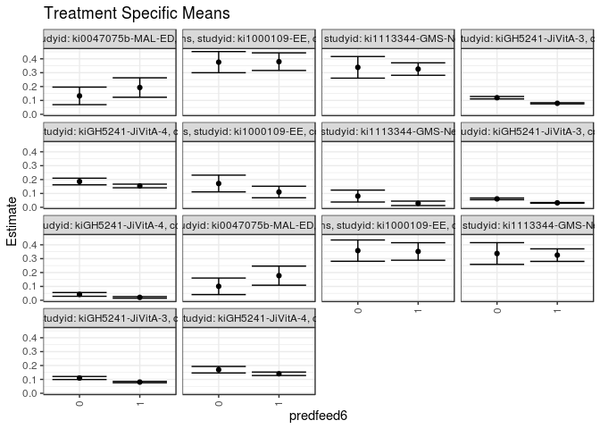

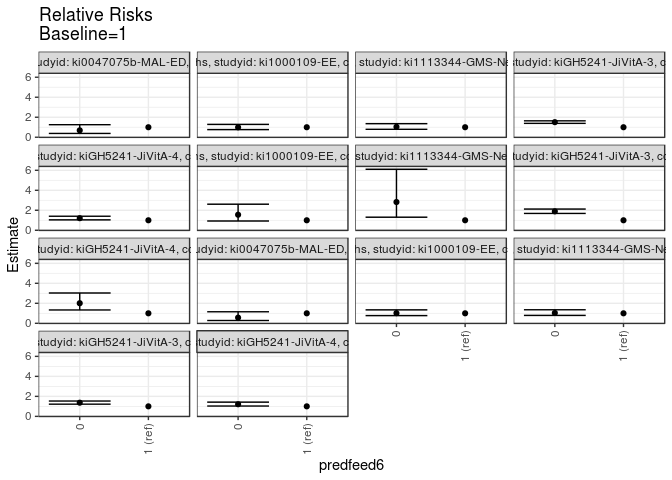

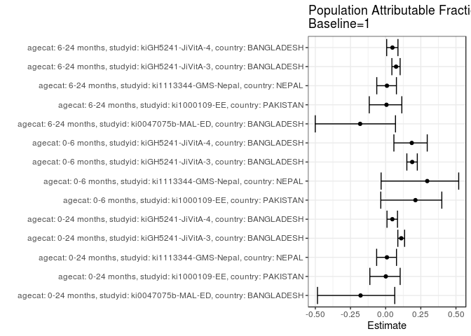

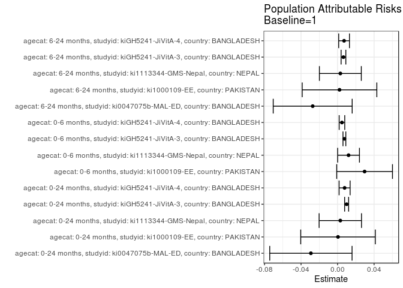

## Results Table

### Parameter: TSM

| agecat | studyid | country | intervention_level | baseline_level | estimate | ci_lower | ci_upper |
| --- | --- | --- | --- | --- | --- | --- | --- |
| 0-24 months | ki0047075b-MAL-ED | BANGLADESH | 1 | NA | 0.1930850 | 0.1231334 | 0.2630367 |
| 0-24 months | ki0047075b-MAL-ED | BANGLADESH | 0 | NA | 0.1328957 | 0.0697038 | 0.1960876 |
| 0-24 months | ki1000109-EE | PAKISTAN | 1 | NA | 0.3794654 | 0.3160119 | 0.4429189 |
| 0-24 months | ki1000109-EE | PAKISTAN | 0 | NA | 0.3759237 | 0.2997678 | 0.4520796 |
| 0-24 months | ki1113344-GMS-Nepal | NEPAL | 1 | NA | 0.3261927 | 0.2813688 | 0.3710165 |
| 0-24 months | ki1113344-GMS-Nepal | NEPAL | 0 | NA | 0.3384877 | 0.2605375 | 0.4164380 |
| 0-24 months | kiGH5241-JiVitA-3 | BANGLADESH | 1 | NA | 0.0794282 | 0.0753033 | 0.0835530 |
| 0-24 months | kiGH5241-JiVitA-3 | BANGLADESH | 0 | NA | 0.1197587 | 0.1110948 | 0.1284226 |
| 0-24 months | kiGH5241-JiVitA-4 | BANGLADESH | 1 | NA | 0.1538747 | 0.1407171 | 0.1670324 |
| 0-24 months | kiGH5241-JiVitA-4 | BANGLADESH | 0 | NA | 0.1859238 | 0.1619110 | 0.2099366 |
| 0-6 months | ki1000109-EE | PAKISTAN | 1 | NA | 0.1102249 | 0.0686284 | 0.1518215 |
| 0-6 months | ki1000109-EE | PAKISTAN | 0 | NA | 0.1714219 | 0.1109929 | 0.2318509 |
| 0-6 months | ki1113344-GMS-Nepal | NEPAL | 1 | NA | 0.0286684 | 0.0127190 | 0.0446177 |
| 0-6 months | ki1113344-GMS-Nepal | NEPAL | 0 | NA | 0.0809559 | 0.0379815 | 0.1239304 |
| 0-6 months | kiGH5241-JiVitA-3 | BANGLADESH | 1 | NA | 0.0321399 | 0.0296512 | 0.0346287 |
| 0-6 months | kiGH5241-JiVitA-3 | BANGLADESH | 0 | NA | 0.0607483 | 0.0548032 | 0.0666935 |
| 0-6 months | kiGH5241-JiVitA-4 | BANGLADESH | 1 | NA | 0.0210929 | 0.0152969 | 0.0268890 |
| 0-6 months | kiGH5241-JiVitA-4 | BANGLADESH | 0 | NA | 0.0424044 | 0.0289371 | 0.0558716 |
| 6-24 months | ki0047075b-MAL-ED | BANGLADESH | 1 | NA | 0.1774556 | 0.1085462 | 0.2463650 |
| 6-24 months | ki0047075b-MAL-ED | BANGLADESH | 0 | NA | 0.1007462 | 0.0412084 | 0.1602840 |
| 6-24 months | ki1000109-EE | PAKISTAN | 1 | NA | 0.3517485 | 0.2885851 | 0.4149120 |
| 6-24 months | ki1000109-EE | PAKISTAN | 0 | NA | 0.3578615 | 0.2812143 | 0.4345086 |
| 6-24 months | ki1113344-GMS-Nepal | NEPAL | 1 | NA | 0.3254852 | 0.2803471 | 0.3706234 |
| 6-24 months | ki1113344-GMS-Nepal | NEPAL | 0 | NA | 0.3370945 | 0.2589001 | 0.4152890 |
| 6-24 months | kiGH5241-JiVitA-3 | BANGLADESH | 1 | NA | 0.0806562 | 0.0756562 | 0.0856563 |
| 6-24 months | kiGH5241-JiVitA-3 | BANGLADESH | 0 | NA | 0.1100608 | 0.0990690 | 0.1210525 |
| 6-24 months | kiGH5241-JiVitA-4 | BANGLADESH | 1 | NA | 0.1403973 | 0.1279232 | 0.1528715 |
| 6-24 months | kiGH5241-JiVitA-4 | BANGLADESH | 0 | NA | 0.1699109 | 0.1464156 | 0.1934061 |

### Parameter: E(Y)

| agecat | studyid | country | intervention_level | baseline_level | estimate | ci_lower | ci_upper |
| --- | --- | --- | --- | --- | --- | --- | --- |
| 0-24 months | ki0047075b-MAL-ED | BANGLADESH | NA | NA | 0.1638655 | 0.1167401 | 0.2109910 |
| 0-24 months | ki1000109-EE | PAKISTAN | NA | NA | 0.3799472 | 0.3310169 | 0.4288776 |
| 0-24 months | ki1113344-GMS-Nepal | NEPAL | NA | NA | 0.3292035 | 0.2904210 | 0.3679861 |
| 0-24 months | kiGH5241-JiVitA-3 | BANGLADESH | NA | NA | 0.0893606 | 0.0854348 | 0.0932864 |
| 0-24 months | kiGH5241-JiVitA-4 | BANGLADESH | NA | NA | 0.1615841 | 0.1496375 | 0.1735306 |
| 0-6 months | ki1000109-EE | PAKISTAN | NA | NA | 0.1398417 | 0.1048786 | 0.1748048 |
| 0-6 months | ki1113344-GMS-Nepal | NEPAL | NA | NA | 0.0407080 | 0.0243991 | 0.0570168 |
| 0-6 months | kiGH5241-JiVitA-3 | BANGLADESH | NA | NA | 0.0396219 | 0.0371297 | 0.0421141 |
| 0-6 months | kiGH5241-JiVitA-4 | BANGLADESH | NA | NA | 0.0259078 | 0.0204779 | 0.0313377 |
| 6-24 months | ki0047075b-MAL-ED | BANGLADESH | NA | NA | 0.1502146 | 0.1042403 | 0.1961889 |
| 6-24 months | ki1000109-EE | PAKISTAN | NA | NA | 0.3538874 | 0.3052956 | 0.4024792 |
| 6-24 months | ki1113344-GMS-Nepal | NEPAL | NA | NA | 0.3285458 | 0.2895051 | 0.3675864 |
| 6-24 months | kiGH5241-JiVitA-3 | BANGLADESH | NA | NA | 0.0871139 | 0.0824317 | 0.0917961 |
| 6-24 months | kiGH5241-JiVitA-4 | BANGLADESH | NA | NA | 0.1475271 | 0.1364035 | 0.1586506 |

### Parameter: RR

| agecat | studyid | country | intervention_level | baseline_level | estimate | ci_lower | ci_upper |
| --- | --- | --- | --- | --- | --- | --- | --- |
| 0-24 months | ki0047075b-MAL-ED | BANGLADESH | 1 | 1 | 1.0000000 | 1.0000000 | 1.000000 |
| 0-24 months | ki0047075b-MAL-ED | BANGLADESH | 0 | 1 | 0.6882756 | 0.3783132 | 1.252199 |
| 0-24 months | ki1000109-EE | PAKISTAN | 1 | 1 | 1.0000000 | 1.0000000 | 1.000000 |
| 0-24 months | ki1000109-EE | PAKISTAN | 0 | 1 | 0.9906667 | 0.7644063 | 1.283899 |
| 0-24 months | ki1113344-GMS-Nepal | NEPAL | 1 | 1 | 1.0000000 | 1.0000000 | 1.000000 |
| 0-24 months | ki1113344-GMS-Nepal | NEPAL | 0 | 1 | 1.0376927 | 0.7931871 | 1.357569 |
| 0-24 months | kiGH5241-JiVitA-3 | BANGLADESH | 1 | 1 | 1.0000000 | 1.0000000 | 1.000000 |
| 0-24 months | kiGH5241-JiVitA-3 | BANGLADESH | 0 | 1 | 1.5077616 | 1.3867481 | 1.639335 |
| 0-24 months | kiGH5241-JiVitA-4 | BANGLADESH | 1 | 1 | 1.0000000 | 1.0000000 | 1.000000 |
| 0-24 months | kiGH5241-JiVitA-4 | BANGLADESH | 0 | 1 | 1.2082801 | 1.0409938 | 1.402449 |
| 0-6 months | ki1000109-EE | PAKISTAN | 1 | 1 | 1.0000000 | 1.0000000 | 1.000000 |
| 0-6 months | ki1000109-EE | PAKISTAN | 0 | 1 | 1.5552008 | 0.9277550 | 2.606992 |
| 0-6 months | ki1113344-GMS-Nepal | NEPAL | 1 | 1 | 1.0000000 | 1.0000000 | 1.000000 |
| 0-6 months | ki1113344-GMS-Nepal | NEPAL | 0 | 1 | 2.8238748 | 1.3066776 | 6.102706 |
| 0-6 months | kiGH5241-JiVitA-3 | BANGLADESH | 1 | 1 | 1.0000000 | 1.0000000 | 1.000000 |
| 0-6 months | kiGH5241-JiVitA-3 | BANGLADESH | 0 | 1 | 1.8901199 | 1.6837974 | 2.121724 |
| 0-6 months | kiGH5241-JiVitA-4 | BANGLADESH | 1 | 1 | 1.0000000 | 1.0000000 | 1.000000 |
| 0-6 months | kiGH5241-JiVitA-4 | BANGLADESH | 0 | 1 | 2.0103582 | 1.3334265 | 3.030943 |
| 6-24 months | ki0047075b-MAL-ED | BANGLADESH | 1 | 1 | 1.0000000 | 1.0000000 | 1.000000 |
| 6-24 months | ki0047075b-MAL-ED | BANGLADESH | 0 | 1 | 0.5677263 | 0.2793657 | 1.153732 |
| 6-24 months | ki1000109-EE | PAKISTAN | 1 | 1 | 1.0000000 | 1.0000000 | 1.000000 |
| 6-24 months | ki1000109-EE | PAKISTAN | 0 | 1 | 1.0173788 | 0.7701059 | 1.344048 |
| 6-24 months | ki1113344-GMS-Nepal | NEPAL | 1 | 1 | 1.0000000 | 1.0000000 | 1.000000 |
| 6-24 months | ki1113344-GMS-Nepal | NEPAL | 0 | 1 | 1.0356676 | 0.7908079 | 1.356344 |
| 6-24 months | kiGH5241-JiVitA-3 | BANGLADESH | 1 | 1 | 1.0000000 | 1.0000000 | 1.000000 |
| 6-24 months | kiGH5241-JiVitA-3 | BANGLADESH | 0 | 1 | 1.3645657 | 1.2165703 | 1.530565 |
| 6-24 months | kiGH5241-JiVitA-4 | BANGLADESH | 1 | 1 | 1.0000000 | 1.0000000 | 1.000000 |
| 6-24 months | kiGH5241-JiVitA-4 | BANGLADESH | 0 | 1 | 1.2102145 | 1.0298051 | 1.422230 |

### Parameter: PAR

| agecat | studyid | country | intervention_level | baseline_level | estimate | ci_lower | ci_upper |
| --- | --- | --- | --- | --- | --- | --- | --- |
| 0-24 months | ki0047075b-MAL-ED | BANGLADESH | 1 | NA | -0.0292195 | -0.0743209 | 0.0158820 |
| 0-24 months | ki1000109-EE | PAKISTAN | 1 | NA | 0.0004818 | -0.0403667 | 0.0413303 |
| 0-24 months | ki1113344-GMS-Nepal | NEPAL | 1 | NA | 0.0030109 | -0.0202099 | 0.0262317 |
| 0-24 months | kiGH5241-JiVitA-3 | BANGLADESH | 1 | NA | 0.0099324 | 0.0077419 | 0.0121229 |
| 0-24 months | kiGH5241-JiVitA-4 | BANGLADESH | 1 | NA | 0.0077093 | 0.0016745 | 0.0137442 |
| 0-6 months | ki1000109-EE | PAKISTAN | 1 | NA | 0.0296167 | -0.0009347 | 0.0601682 |
| 0-6 months | ki1113344-GMS-Nepal | NEPAL | 1 | NA | 0.0120396 | 0.0001015 | 0.0239777 |
| 0-6 months | kiGH5241-JiVitA-3 | BANGLADESH | 1 | NA | 0.0074820 | 0.0059323 | 0.0090317 |
| 0-6 months | kiGH5241-JiVitA-4 | BANGLADESH | 1 | NA | 0.0048149 | 0.0017619 | 0.0078678 |
| 6-24 months | ki0047075b-MAL-ED | BANGLADESH | 1 | NA | -0.0272410 | -0.0704983 | 0.0160163 |
| 6-24 months | ki1000109-EE | PAKISTAN | 1 | NA | 0.0021389 | -0.0387452 | 0.0430229 |
| 6-24 months | ki1113344-GMS-Nepal | NEPAL | 1 | NA | 0.0030605 | -0.0199009 | 0.0260220 |
| 6-24 months | kiGH5241-JiVitA-3 | BANGLADESH | 1 | NA | 0.0064577 | 0.0038756 | 0.0090397 |
| 6-24 months | kiGH5241-JiVitA-4 | BANGLADESH | 1 | NA | 0.0071297 | 0.0012309 | 0.0130286 |

### Parameter: PAF

| agecat | studyid | country | intervention_level | baseline_level | estimate | ci_lower | ci_upper |
| --- | --- | --- | --- | --- | --- | --- | --- |
| 0-24 months | ki0047075b-MAL-ED | BANGLADESH | 1 | NA | -0.1783137 | -0.4846424 | 0.0648097 |
| 0-24 months | ki1000109-EE | PAKISTAN | 1 | NA | 0.0012681 | -0.1122414 | 0.1031935 |
| 0-24 months | ki1113344-GMS-Nepal | NEPAL | 1 | NA | 0.0091460 | -0.0639485 | 0.0772188 |
| 0-24 months | kiGH5241-JiVitA-3 | BANGLADESH | 1 | NA | 0.1111498 | 0.0867324 | 0.1349144 |
| 0-24 months | kiGH5241-JiVitA-4 | BANGLADESH | 1 | NA | 0.0477110 | 0.0096006 | 0.0843548 |
| 0-6 months | ki1000109-EE | PAKISTAN | 1 | NA | 0.2117877 | -0.0344762 | 0.3994268 |
| 0-6 months | ki1113344-GMS-Nepal | NEPAL | 1 | NA | 0.2957548 | -0.0323151 | 0.5195640 |
| 0-6 months | kiGH5241-JiVitA-3 | BANGLADESH | 1 | NA | 0.1888346 | 0.1508237 | 0.2251440 |
| 0-6 months | kiGH5241-JiVitA-4 | BANGLADESH | 1 | NA | 0.1858468 | 0.0586879 | 0.2958283 |
| 6-24 months | ki0047075b-MAL-ED | BANGLADESH | 1 | NA | -0.1813471 | -0.5006289 | 0.0700026 |
| 6-24 months | ki1000109-EE | PAKISTAN | 1 | NA | 0.0060440 | -0.1164595 | 0.1151057 |
| 6-24 months | ki1113344-GMS-Nepal | NEPAL | 1 | NA | 0.0093154 | -0.0630971 | 0.0767955 |
| 6-24 months | kiGH5241-JiVitA-3 | BANGLADESH | 1 | NA | 0.0741290 | 0.0443453 | 0.1029845 |
| 6-24 months | kiGH5241-JiVitA-4 | BANGLADESH | 1 | NA | 0.0483283 | 0.0074032 | 0.0875661 |